# Determinants of body mass in wild giraffe (pd25082)

Mohd Kamran Khan

14th Dec 2025

# Background

The persistence of wildlife populations can be impacted by body mass, which is a significant determinant of individual health and survival (Clements & Ozgul 2016; Cerini et al. 2023). African ungulates are essential to the health of ecosystems, and conservation requires an understanding of the factors influencing body mass.

The objective of this study is to determine the environmental and ecological factors that influence giraffe body mass (kg), taking into consideration any potential systematic bias resulting from variations in parks and observers.

# Data

In order to comprehend the data format. The final dataset consisted of 290 individual giraffes, each contributing a kilogram-based single body mass measurement. Environmental predictors comprised both categorical descriptors of habitat and site characteristics and continuous factors, such as average annual rainfall, distance to water, and predator population. A hierarchical structure with possible site-level and observer-related variation was produced by gathering data from several parks and observers.

```r
# # Load required packages for data manipulation and cleaning
library(tidyverse)
library(janitor)
#  Read the dataset and standardise column names

dat_long <- read_tsv("mass_pd25082.tsv.gz") |>
  clean_names()
glimpse(dat_long)
```

```
## Rows: 870
## Columns: 10
## $ student_id    <chr> "pd25082", "pd25082", "pd25082", "pd25082", "pd25082", "…
## $ species       <chr> "Giraffe", "Giraffe", "Giraffe", "Giraffe", "Giraffe", "…
## $ park          <chr> "Savanna Whisper Reserve", "Savanna Whisper Reserve", "S…
## $ observer      <chr> "Obs_3", "Obs_3", "Obs_3", "Obs_1", "Obs_1", "Obs_1", "O…
## $ body_mass     <dbl> 1160.4082, 1160.4082, 1160.4082, 1414.1663, 1414.1663, 1…
## $ landscape     <chr> "Flat", "Flat", "Flat", "Flat", "Flat", "Flat", "Flat", …
## $ vegetation    <chr> "Dense", "Dense", "Dense", "Open", "Open", "Open", "Open…
## $ lion_presence <chr> "Present", "Present", "Present", "Present", "Present", "…
## $ env_var       <chr> "distance_to_water_km", "average_annual_rainfall_mm", "p…
## $ env_value     <dbl> 4.0619944, 592.5762822, 0.6602755, 3.2772415, 1054.55415…
```

# Individuals & reshaping

Despite the fact that each giraffe’s body mass (kg) was only measured once, the dataset was given in a lengthy format with each individual appearing in several rows that corresponded to various environmental factors. These repeating rows indicate triplicate measures linked to the same person rather than independent observations, as the coursework instructions make clear.

The premise of independence would be broken and the sample size would be artificially increased if these rows were treated as distinct people. I established a unique person identity and rearranged the dataset so that each row matched to a single individual, with environmental factors saved as distinct columns, in order to guarantee that each giraffe was represented only once in the analysis. This reorganization made it possible to analyze body mass at the individual’s biologically significant level while keeping all relevant environmental data.

```r
#  Each individual appears as three rows (one per environmental variable);
# create an individual ID assuming triplicate measurements per individual

dat_long <- dat_long |>
  mutate(ind_id = (row_number() - 1) %/% 3 + 1)

# Reshape data so each row represents one individual
dat <- dat_long |>
  pivot_wider(
    id_cols = c(ind_id, student_id, species, park, observer,
                body_mass, landscape, vegetation, lion_presence),
    names_from = env_var,
    values_from = env_value
  )

glimpse(dat)
```

```
## Rows: 290
## Columns: 12
## $ ind_id                     <dbl> 1, 2, 3, 4, 5, 6, 7, 8, 9, 10, 11, 12, 13, …
## $ student_id                 <chr> "pd25082", "pd25082", "pd25082", "pd25082",…
## $ species                    <chr> "Giraffe", "Giraffe", "Giraffe", "Giraffe",…
## $ park                       <chr> "Savanna Whisper Reserve", "Golden Tusk Saf…
## $ observer                   <chr> "Obs_3", "Obs_1", "Obs_5", "Obs_5", "Obs_1"…
## $ body_mass                  <dbl> 1160.4082, 1414.1663, 1073.7820, 879.7941, …
## $ landscape                  <chr> "Flat", "Flat", "Flat", "Hilly", "Flat", "H…
## $ vegetation                 <chr> "Dense", "Open", "Open", NA, "Dense", "Open…
## $ lion_presence              <chr> "Present", "Present", "Absent", "Present", …
## $ distance_to_water_km       <dbl> 4.0619944, 3.2772415, 1.7929525, 7.0097153,…
## $ average_annual_rainfall_mm <dbl> 592.5763, 1054.5542, 1049.4523, 1109.2344, …
## $ predator_density_per_sq_km <dbl> 0.6602755, 1.7474653, NA, 0.2670211, 0.6327…
```

# Data cleaning

I checked the categorical variables for clear formatting mistakes and spelling inconsistencies, such as different or misspelled labels that represented the same category, before beginning any analysis. To guarantee that every category was handled uniformly throughout the dataset, these discrepancies were standardized. Furthermore, all grouping variables were explicitly changed to factors, including park, observer, habitat type, and landscape. In order to prevent categorical predictors from being mistakenly handled as continuous variables, this step was required to guarantee that the statistical models and visualization tools appropriately interpreted them.

```r
dat <- dat |>
  mutate(
    lion_presence = case_when(
      lion_presence %in% c("Present","Preseet","Preesnt") ~ "Present",
      lion_presence %in% c("Absent","Asbent") ~ "Absent",
      TRUE ~ lion_presence
    ),
    across(c(park, observer, landscape, vegetation, lion_presence), as.factor)
  )
```

# Exploratory analysis

These exploratory patterns were utilized to inform model specification and direct the choice of suitable predictors rather than to make formal conclusions. The general distribution of giraffe body mass was visualized using a histogram, and color was added to enhance clarity and facilitate interpretation.

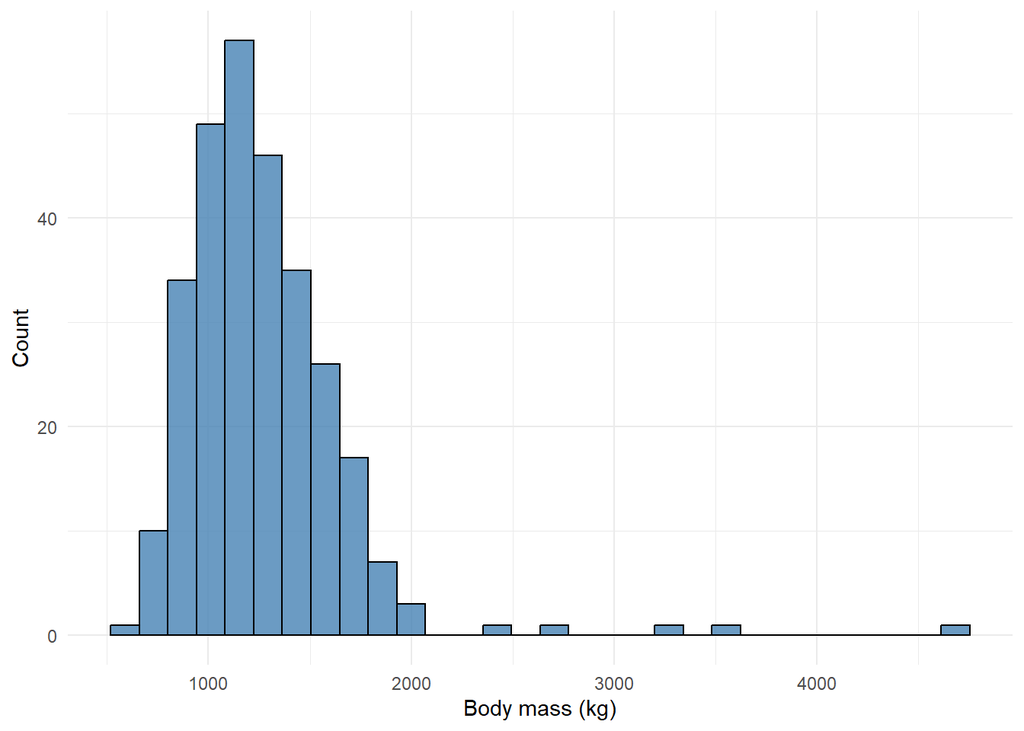

```r
ggplot(dat, aes(body_mass)) +
  geom_histogram(
    bins = 30,
    fill = "steelblue",
    colour = "black",
    alpha = 0.8
  ) +
  labs(x = "Body mass (kg)", y = "Count") +
  theme_minimal()
```

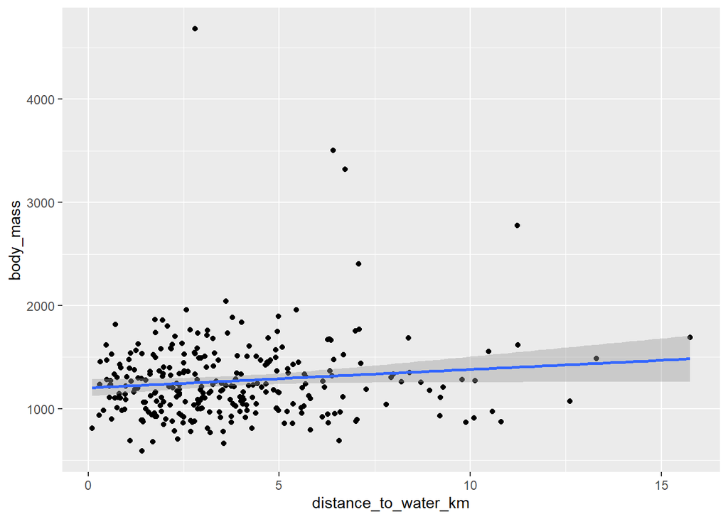

```r
ggplot(dat, aes(distance_to_water_km, body_mass)) +
  geom_point() +
  geom_smooth(method = "lm")
```

# Visualisation

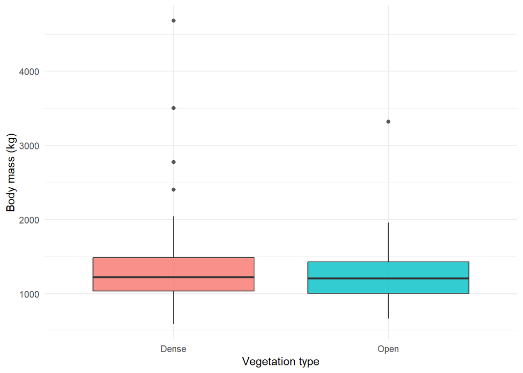

```r
  ggplot(
  dat |> filter(!is.na(vegetation)),
  aes(x = vegetation, y = body_mass, fill = vegetation)
) +
  geom_boxplot(alpha = 0.8) +
  theme_minimal() +
  labs(x = "Vegetation type", y = "Body mass (kg)") +
  theme(legend.position = "none")
```

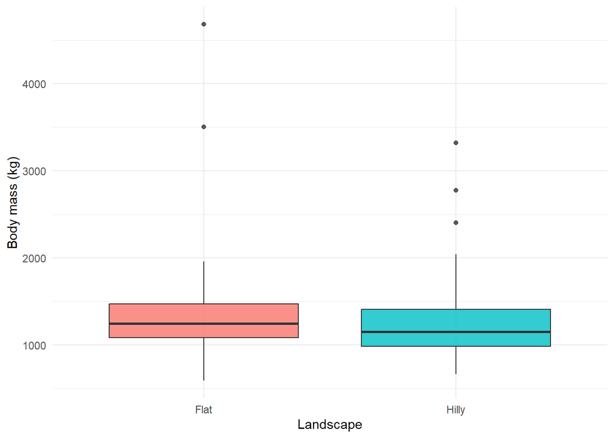

```r
ggplot(
  dat |> filter(!is.na(landscape)),
  aes(x = landscape, y = body_mass, fill = landscape)
) +
  geom_boxplot(alpha = 0.8) +
  theme_minimal() +
  labs(x = "Landscape", y = "Body mass (kg)") +
  theme(legend.position = "none")
```

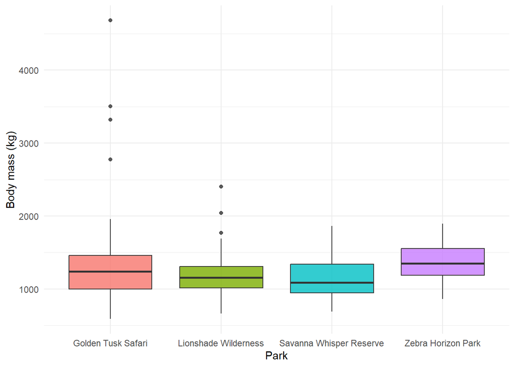

```r
ggplot(
  dat,
  aes(x = park, y = body_mass, fill = park)
) +
  geom_boxplot(alpha = 0.8) +
  theme_minimal() +
  labs(x = "Park", y = "Body mass (kg)") +
  theme(legend.position = "none")
```

# Statistical model

Because body mass is a continuous variable and measurements were collected from multiple parks and observers, I developed a linear mixed-effects model. Baseline body mass can differ between sites and observers by using park and observer as random intercepts rather than estimating a distinct fixed effect for every level. This method increases the generality of fixed effect estimates, lowers the possibility of pseudoreplication, and takes non-independence among observations into consideration. The Gaussian error structure’s presumptions were sufficiently satisfied, according to residual diagnostics. Park and the observer were included as random effects to account for systematic bias. Body mass was log-transformed to enhance residual behavior. A log-normal distribution of body mass on the original scale is equivalent to the model’s assumption of normally distributed residuals.

```r
library(lme4)
library(lmerTest)
dat <- dat |> mutate(log_mass = log(body_mass))

# Fit a linear mixed-effects model with park and observer as random effects
# Body mass is log-transformed to improve residual behaviour
m1 <- lmer(
  log_mass ~
    scale(average_annual_rainfall_mm) +
    scale(distance_to_water_km) +
    scale(predator_density_per_sq_km) +
    vegetation + landscape + lion_presence +
    (1 | park) + (1 | observer),
  data = dat
)

summary(m1)
```

```
## Linear mixed model fit by REML. t-tests use Satterthwaite's method [
## lmerModLmerTest]
## Formula:
## log_mass ~ scale(average_annual_rainfall_mm) + scale(distance_to_water_km) +
##     scale(predator_density_per_sq_km) + vegetation + landscape +
##     lion_presence + (1 | park) + (1 | observer)
##    Data: dat
##
## REML criterion at convergence: 52.3
##
## Scaled residuals:
##     Min      1Q  Median      3Q     Max
## -3.4963 -0.5575  0.0005  0.5193  4.7408
##
## Random effects:
##  Groups   Name        Variance Std.Dev.
##  observer (Intercept) 0.007270 0.08526
##  park     (Intercept) 0.005929 0.07700
##  Residual             0.059233 0.24338
## Number of obs: 274, groups:  observer, 5; park, 4
##
## Fixed effects:
##                                     Estimate Std. Error         df t value
## (Intercept)                         7.143650   0.061964   8.860767 115.286
## scale(average_annual_rainfall_mm)  -0.018803   0.015371 261.108092  -1.223
## scale(distance_to_water_km)         0.047338   0.015081 261.481211   3.139
## scale(predator_density_per_sq_km)   0.001253   0.015041 261.847035   0.083
## vegetationOpen                     -0.061029   0.029748 261.025087  -2.052
## landscapeHilly                     -0.045144   0.029741 260.927616  -1.518
## lion_presencePresent                0.033038   0.030500 261.698506   1.083
##                                   Pr(>|t|)
## (Intercept)                       2.21e-15 ***
## scale(average_annual_rainfall_mm)  0.22231
## scale(distance_to_water_km)        0.00189 **
## scale(predator_density_per_sq_km)  0.93368
## vegetationOpen                     0.04121 *
## landscapeHilly                     0.13025
## lion_presencePresent               0.27971
## ---
## Signif. codes:  0 '***' 0.001 '**' 0.01 '*' 0.05 '.' 0.1 ' ' 1
##
## Correlation of Fixed Effects:
##             (Intr) scl(v___) scl(d___) s(____ vgttnO lndscH
## scl(vrg___) -0.028
## scl(dst___)  0.015  0.087
## scl(pr____) -0.057  0.142     0.020
## vegetatnOpn -0.245 -0.054    -0.069     0.030
## landscpHlly -0.231 -0.029    -0.044     0.054  0.041
## ln_prsncPrs -0.242  0.161     0.069     0.130 -0.025 -0.063
```

# Model diagnostics

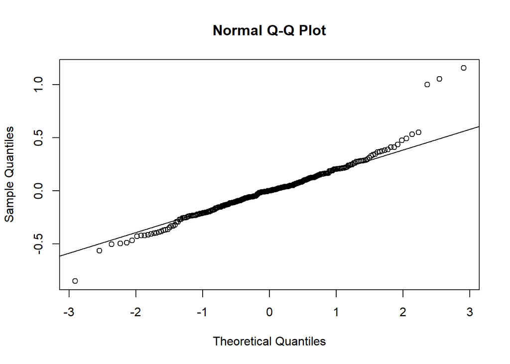

```r
qqnorm(resid(m1))
qqline(resid(m1))
```

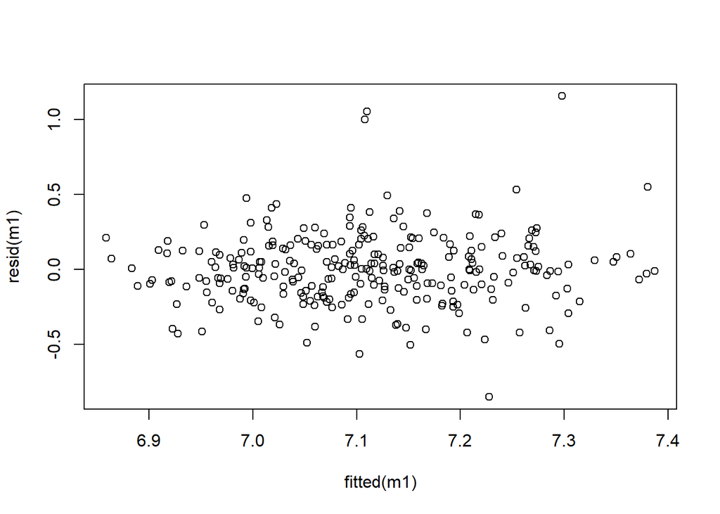

```r
plot(fitted(m1), resid(m1))
```

# Results

Giraffe body mass clearly correlated with plant type and distance to water after controlling for systematic variations between parks and observers. Body mass rose as the distance to the water grew (estimate = 0.047, p = 0.0019), or around 5% more mass per standard deviation increase in distance. The body mass of giraffes in open vegetation was considerably lower than that of animals in dense vegetation (estimate = −0.061, p = 0.041), which is equivalent to a 6% decrease in mass.

The average annual rainfall, predator density, topography, and presence of lions did not significantly affect body mass (all p > 0.05).

The lack of statistically significant effects for lion presence, landscape, rainfall, and predator density does not mean that these factors are insignificant. Instead, it shows that, after accounting for site-level and observer-related variation, there was not enough evidence to find consistent relationships between these characteristics and body mass within the parameters of the available data.

Body mass increased with increasing distance to water.

```r
library(broom.mixed)
tidy(m1, effects = "fixed", conf.int = TRUE)
```

```
## # A tibble: 7 × 9
##   effect term    estimate std.error statistic     df  p.value conf.low conf.high
##   <chr>  <chr>      <dbl>     <dbl>     <dbl>  <dbl>    <dbl>    <dbl>     <dbl>
## 1 fixed  (Inter…  7.14       0.0620  115.       8.86 2.21e-15   7.00     7.28
## 2 fixed  scale(… -0.0188     0.0154   -1.22   261.   2.22e- 1  -0.0491   0.0115
## 3 fixed  scale(…  0.0473     0.0151    3.14   261.   1.89e- 3   0.0176   0.0770
## 4 fixed  scale(…  0.00125    0.0150    0.0833 262.   9.34e- 1  -0.0284   0.0309
## 5 fixed  vegeta… -0.0610     0.0297   -2.05   261.   4.12e- 2  -0.120   -0.00245
## 6 fixed  landsc… -0.0451     0.0297   -1.52   261.   1.30e- 1  -0.104    0.0134
## 7 fixed  lion_p…  0.0330     0.0305    1.08   262.   2.80e- 1  -0.0270   0.0931
```

# Discussion

This analysis shows that the spatial distribution of resources and the shape of the habitat affect giraffe body mass. Since giraffes are less dependent on frequent access to water than many other ungulates, higher body mass at farther distances from water may indicate less competition or availability to higher-quality feed. Reduced browsing chances in more open settings are linked with lower body mass in open vegetation as opposed to thick vegetation.

There are a few restrictions to be aware of. There is limited insight into temporal variations in body mass because the data are a snapshot in time and do not include repeated assessments of people. Furthermore, some of the remaining variation may be explained by potentially significant individual-level factors that were not accessible, such as age, sex, and reproductive status. A more thorough knowledge of the factors influencing body mass would be possible with future research that included longitudinal data and additional biological variables.

Because body condition is directly related to survival and reproductive success, it is crucial from a conservation standpoint to discover habitat factors linked to higher body mass. These findings demonstrate how habitat structure and spatial resource distribution may contribute to the maintenance of healthy giraffe populations in the face of shifting environmental conditions.

# References

Clements & Ozgul (2016) Nature Communications 7(1), 10984  
Cerini et al. (2023) Nature Ecology & Evolution 7(3), 320–333